# Lab 4: Statistics

Histograms, Barplots, Lineplots

In this lab, we’ll continue exploring the basics of ggplot2, focusing on barplots, lineplots, and revisiting histograms. As we’ve discussed in class, histograms are powerful tools for understanding how frequently or infrequently certain values occur in our dataset.

Historgrams

Barplots

Lineplots

Author

Bogdan G. Popescu

# 1 Intro

Open a new Quarto document. Select all text by pressing Ctrl + A (Windows) or Cmd + A (Mac), then press Delete. Next, copy and paste the following preamble.

```yaml
---
title: "Lab 4"
author: "Your Name"
date: "September 13, 2024"
format:
  html:
    toc: true
    number-sections: true
    colorlinks: true
    smooth-scroll: true
    embed-resources: true
---
```

Render the document and save it under “week4” in your “stats” folder.

# 2 Background

To understand better how histograms work, imagine a set of values that are spaced out along a number line.

[figure not shown]

To construct a histogram, a section of the number line is divided into equal chunks, called **bins**. Next, count how many data points sit inside each bin, and draw bars, one for each bin, whose heights correspond to the number of data points.

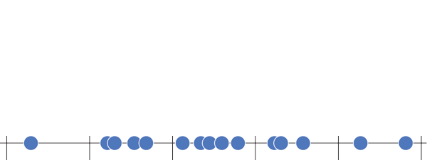

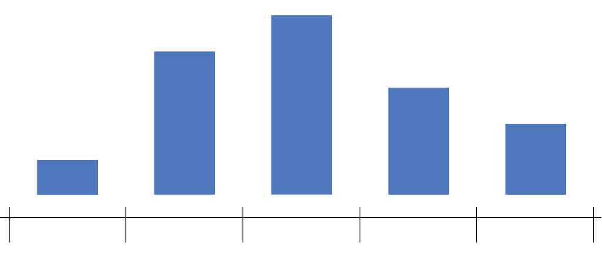